# Cluster Analysis

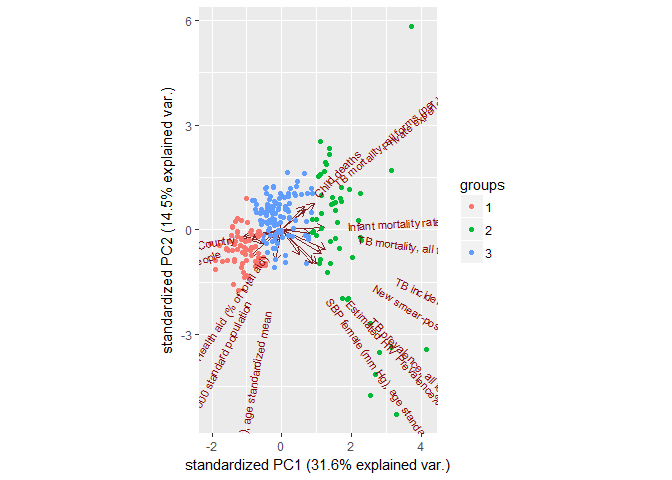

سوال 5 برای شاخص تحصیلات

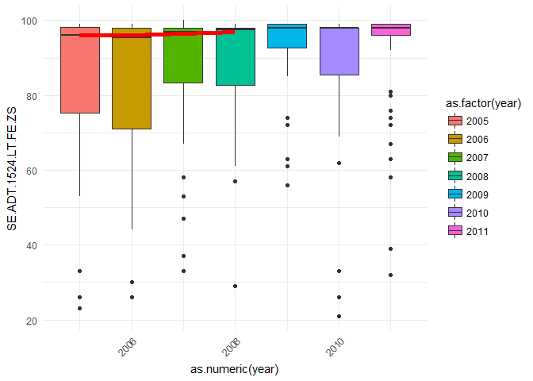

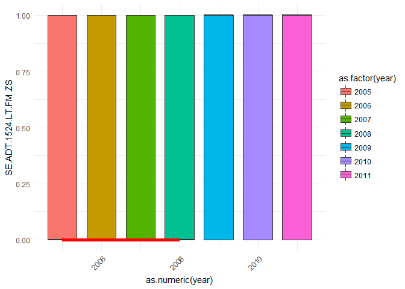

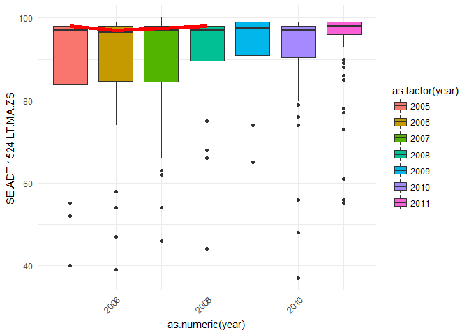

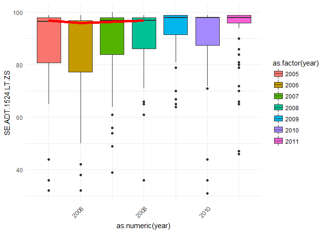

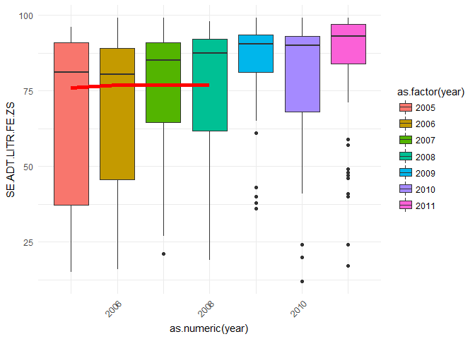

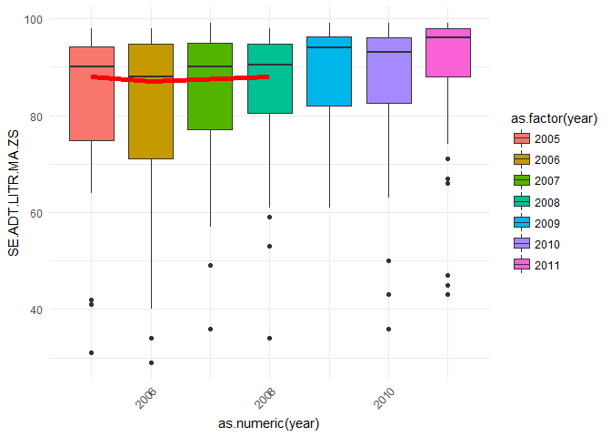

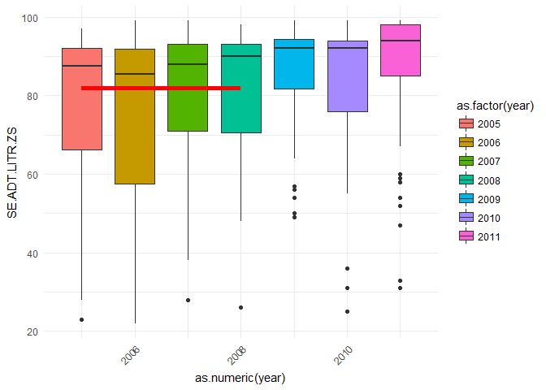

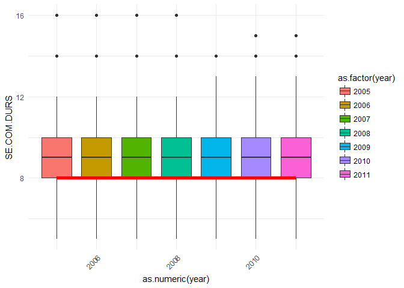

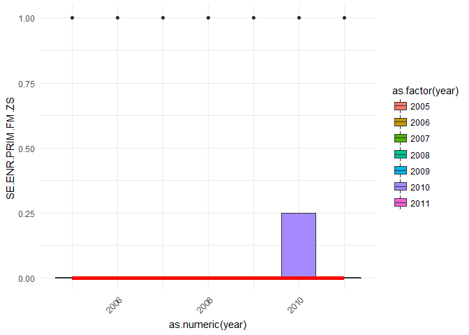

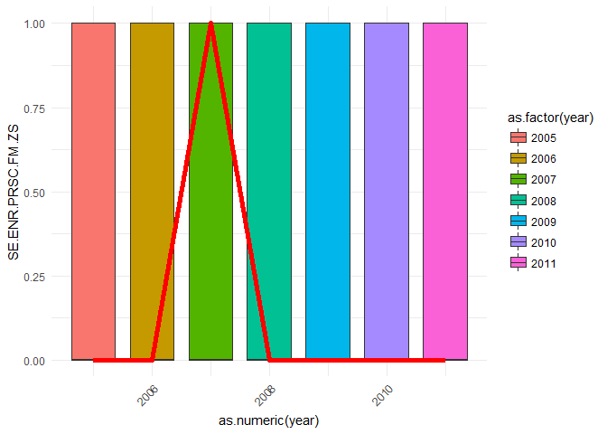

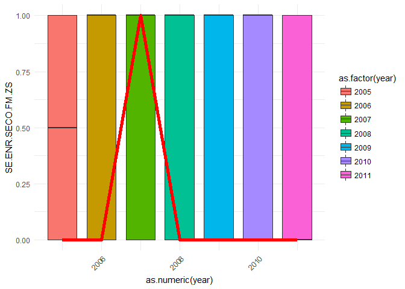

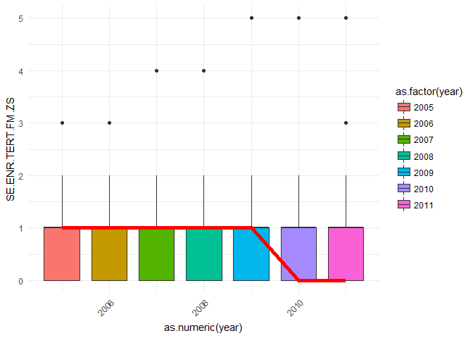

[5 more figures not shown]

سوال 6 برای شاخص تحصیلات

```
## K-means clustering with 3 clusters of sizes 131, 103, 30
##
## Cluster means:
##   SE.ADT.1524.LT.FE.ZS SE.ADT.1524.LT.FM.ZS SE.ADT.1524.LT.MA.ZS
## 1            0.0359571           0.08208086           0.03122454
## 2            0.5404893           0.49549025           0.51861751
## 3           -2.0126926          -2.05960294          -1.91693393
##   SE.ADT.1524.LT.ZS SE.ADT.LITR.FE.ZS SE.ADT.LITR.MA.ZS SE.ADT.LITR.ZS
## 1        0.03506206       -0.04639311       -0.01458314     -0.0309586
## 2        0.53383470        0.59946203        0.56567151      0.5894875
## 3       -1.98593678       -1.85556974       -1.87845911     -1.8887213
##   SE.COM.DURS SE.ENR.PRIM.FM.ZS SE.ENR.PRSC.FM.ZS SE.ENR.SECO.FM.ZS
## 1  -0.1981136        0.04081327        0.04335386        0.08082556
## 2   0.3668542        0.48454430        0.51476375        0.46747292
## 3  -0.3944367       -1.84182006       -1.95666740       -1.95792864
##   SE.ENR.TERT.FM.ZS SE.PRE.DURS SE.PRE.ENRL.TC.ZS SE.PRE.ENRR
## 1        -0.1419083  -0.2159761         0.1405693  -0.3433811
## 2         0.5294361   0.2197734        -0.5664442   0.8133115
## 3        -1.1980644   0.1885404         1.3309726  -1.2929388
##   SE.PRE.ENRR.FE SE.PRE.ENRR.MA SE.PRE.TCAQ.FE.ZS SE.PRE.TCAQ.MA.ZS
## 1     -0.3496755     -0.3490331        -0.1391989       -0.06359088
## 2      0.8238230      0.8205907         0.3143685        0.27509855
## 3     -1.3015426     -1.2932501        -0.4714966       -0.66682485
##   SE.PRE.TCAQ.ZS SE.PRM.AGES SE.PRM.CMPT.FE.ZS SE.PRM.CMPT.MA.ZS
## 1     -0.1313692 -0.14341308        -0.0420259       -0.08480754
## 2      0.3433137  0.08465165         0.6342996        0.61420021
## 3     -0.6050651  0.33559979        -1.9942487       -1.73842780
##   SE.PRM.CMPT.ZS SE.PRM.CUAT.FE.ZS SE.PRM.CUAT.MA.ZS SE.PRM.CUAT.ZS
## 1    -0.06011928        -0.2025884        -0.1796066     -0.1938427
## 2     0.62784863         0.4779908         0.4305947      0.4618106
## 3    -1.89309277        -0.7564657        -0.6940930     -0.7391032
##   SE.PRM.DURS SE.PRM.ENRL SE.PRM.ENRL.FE.ZS
## 1   0.2218089  0.10480527        0.08650201
## 2  -0.3426153 -0.11795251        0.36138043
## 3   0.2077473 -0.05267937       -1.61846492
##
## Clustering vector:
##                                          Afghanistan
##                                                    3
##                                              Albania
```

[output cut: 520 more lines]

```
##                                                    1
##                                               Zambia
##                                                    1
##                                             Zimbabwe
##                                                    1
##
## Within cluster sum of squares by cluster:
## [1] 2159.805 1925.066 1023.358
##  (between_SS / total_SS =  35.3 %)
##
## Available components:
##
## [1] "cluster"      "centers"      "totss"        "withinss"
## [5] "tot.withinss" "betweenss"    "size"         "iter"
## [9] "ifault"
```

سوال 7 برای شاخص تحصیلات

```
## K-means clustering with 3 clusters of sizes 115, 119, 30
##
## Cluster means:
##          PC1        PC2
## 1 -0.5303305  0.6009996
## 2  2.4859607 -0.5531131
## 3 -7.8280440 -0.1098167
##
## Clustering vector:
##                                          Afghanistan
##                                                    3
##                                              Albania
##                                                    2
##                                              Algeria
##                                                    1
##                                       American Samoa
##                                                    1
##                                              Andorra
##                                                    1
##                                               Angola
##                                                    1
##                                  Antigua and Barbuda
##                                                    2
##                                           Arab World
##                                                    1
##                                            Argentina
##                                                    2
##                                              Armenia
##                                                    2
##                                                Aruba
##                                                    2
##                                            Australia
##                                                    2
##                                              Austria
##                                                    2
##                                           Azerbaijan
##                                                    2
##                                         Bahamas, The
##                                                    2
##                                              Bahrain
```

[output cut: 492 more lines]

```
##                                                    1
##                                               Zambia
##                                                    1
##                                             Zimbabwe
##                                                    1
##
## Within cluster sum of squares by cluster:
## [1] 377.5844 639.2186 332.3920
##  (between_SS / total_SS =  66.6 %)
##
## Available components:
##
## [1] "cluster"      "centers"      "totss"        "withinss"
## [5] "tot.withinss" "betweenss"    "size"         "iter"
## [9] "ifault"
```

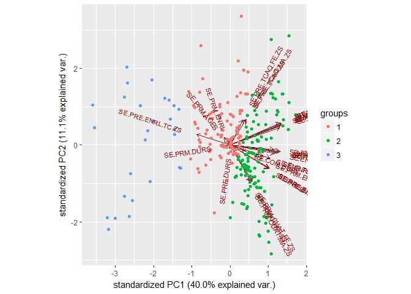

۱۰. کشورهای دنیا را بر حسب ۶۰ شاخص اقتصادی، سلامت و آموزش با روش سلسله مراتبی خوشه بندی کرده و دندروگرام آن را رسم نمایید. اگر داده ها بر سه دسته تقسیم شوند ایران در کدام دسته می گنجد؟

چون امکان نمایش دادن هر 250 کشور زمین را نداریم، تنها ده درصد ازین کشور ها به علاوه ایران را بر روی نمودار نمایش میدهیم.

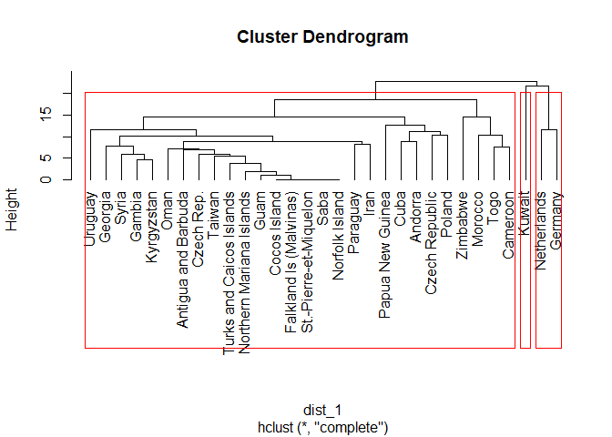

***

۱۱. سه یافته جالب از داده ها استخراج کنید.

سعی میکنیم با پردازش داده تاثیرات جنگ 8 ساله ایران و عراق را بر وضع زندگی مردم ایران نشان دهیم. این جنگ از سال 1980 شروع شد و تا سال 1988 ادامه یافت. همچنین انقلاب اسلامی ایران یکسال قبل یعنی سال 1979 به پیروزی رسید.

ابتدا تاثیر جنگ را بر روی میزان امید به زندگی ایرانی ها میسنجیم. مشاهده میشود که با شروع جنگ امید به زندگی ایرانی ها 4 سال کاهش یافته است.

[interactive chart not shown]

همچنین نمودار درامد سالانه ایرانی ها رسم شده است. شاهد کاهش درامد در سال های آغازی انقلاب هستیم. در چند سال اخیر نیز درامد روند افزایشی داشته است.

[interactive chart not shown]

حال سعی میکنیم وضعیت واردات و صادرات ایران را مورد بررسی قرار بدهیم.ابتدا با کشیدن نمودار و آزمون فرض غیر پارامتریک wilcoxon صادرات و واردات را در سال های مختلف مقایسه کردیم. فرض صفر این آزمون عبارت است از یکسان بودن توزیع واردات و صادرات که با توجه به p-value به دست آمده نتوانستیم این فرض را رد کنیم. پس نمیتوان در مورد ایران نتیجه گرفت که واردات از صادرات به طور چشمگیری بیشتر است و برعکس

```
##
##  Wilcoxon signed rank test
##
## data:  as.numeric(iran_import_export$Export) and as.numeric(iran_import_export$Import)
## V = 594, p-value = 0.1469
## alternative hypothesis: true location shift is not equal to 0
```

[interactive chart not shown]

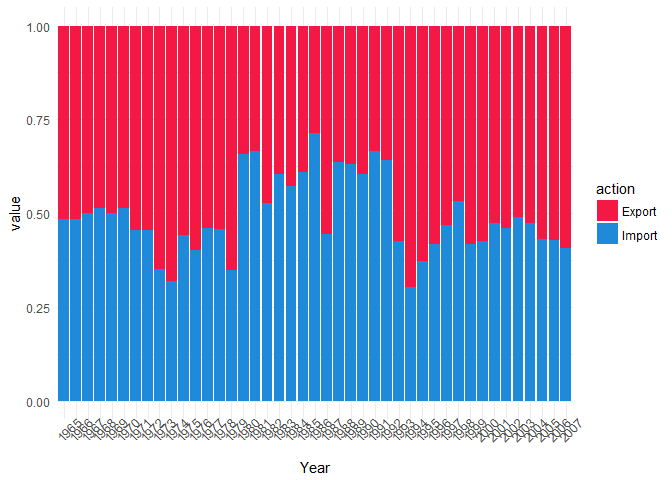

[interactive chart not shown]

در زیر سعی میکنیم میزان سرمایه گذاری ایرانی ها را پیشبینی کنیم.

توقع داریم میزان سرمایه گذاری با مواردی مثل میزان واردات و صادرات کشور و درامد مردم دارای ارتباط باشد. سعی میکنیم این ارتباط را به صورت خطی مدل کنیم.

```r
investment %>%
  filter(`Foreign direct investment, net inflows (% of GDP)` == "Iran") %>%
  gather("year", "value", -1) -> Iran_investment

colnames(Iran_investment) = c("Country", "Year", "Investment")

Income %>%
  filter(`GDP per capita PPP, with projections` == "Iran") %>%
  gather("year", "income", -1) -> IranIncome
colnames(IranIncome) = c("Country", "Year", "Income")


full_join(IranIncome, iran_import_export) %>%
  full_join(Iran_investment) -> Iran_economy
Iran_economy %>% drop_na() -> Iran_economy


Iran_economy %>% head(5)
```

```
## # A tibble: 5 x 6
##   Country Year  Income Export Import      Investment
##   <chr>   <chr>  <dbl>  <dbl> <chr>       <chr>
## 1 Iran    1970   7247.   19.2 19.74951658 0.264449012
## 2 Iran    1971   7933.   24.1 19.92677374 0.493810035
## 3 Iran    1972   8985.   24.1 20.27852015 0.557913685
## 4 Iran    1973   9504.   35.2 19.49276854 2.177260334
## 5 Iran    1974  10073.   49.4 22.51097628 0.729737618
```

```r
model = lm(data = Iran_economy , formula = as.numeric(Investment) ~ as.numeric(Income) + as.numeric(Import) + as.numeric(Export))
summary(model)
```

```
##
## Call:
## lm(formula = as.numeric(Investment) ~ as.numeric(Income) + as.numeric(Import) +
##     as.numeric(Export), data = Iran_economy)
##
## Residuals:
##      Min       1Q   Median       3Q      Max
## -1.47328 -0.30566 -0.18050  0.08658  2.44189
##
## Coefficients:
##                      Estimate Std. Error t value Pr(>|t|)
## (Intercept)        -1.4791274  0.7389694  -2.002   0.0539 .
## as.numeric(Income)  0.0001565  0.0001224   1.278   0.2103
## as.numeric(Import)  0.0218418  0.0263133   0.830   0.4126
## as.numeric(Export)  0.0092312  0.0192937   0.478   0.6356
## ---
## Signif. codes:  0 '***' 0.001 '**' 0.01 '*' 0.05 '.' 0.1 ' ' 1
##
## Residual standard error: 0.6933 on 32 degrees of freedom
## Multiple R-squared:  0.2922, Adjusted R-squared:  0.2258
## F-statistic: 4.403 on 3 and 32 DF,  p-value: 0.01058
```